```r
library(rjags)
library(loo)
library(coda)
```

```r
rm(list=ls())
lf = read.csv("data/hourly_load_factor.csv")
dim(lf); head(lf); summary(lf$load_factor)
```

```
## [1] 2000    3
```

```
##        date hour load_factor
## 1 3/18/2017    0     0.67677
## 2 1/18/2017    1     0.53322
## 3  7/7/2017   18     0.75073
## 4 6/17/2017    4     0.61787
## 5  6/2/2017    9     0.58899
## 6  4/6/2017    6     0.51257
```

```
##    Min. 1st Qu.  Median    Mean 3rd Qu.    Max.
##  0.4257  0.5860  0.7329  0.7235  0.8042  0.9990
```

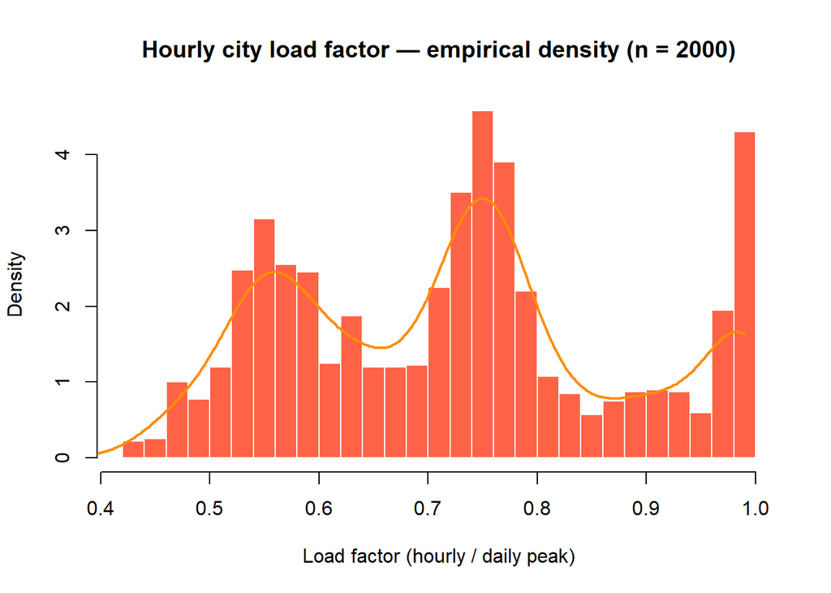

```r
hist(lf$load_factor, breaks = 35, freq = FALSE,
     col = "tomato", border = "white",
     xlab = "Load factor (hourly / daily peak)",
     main = "Hourly city load factor — empirical density (n = 2000)")
lines(density(lf$load_factor, from = 0.01, to = 0.99),
      col = "darkorange", lwd = 2)
```

# Task 1

**Objective:** Compare a single Beta vs Beta mixture model with $H = 1, 2, 3, 4, 5$, with model selection via WAIC.

## Mathematical Formulation: Beta Mixture Model (BMM)

A **Beta Mixture Model** with $H$ components expresses the probability density function (PDF) of a continuous random variable $X$ (where $X \in (0,1)$) as a convex combination of $H$ distinct Beta distributions.

The overall density function is defined as:

$$f(x; \boldsymbol{\pi},
\boldsymbol{\alpha}, \boldsymbol{\beta}) = \sum_{h=1}^H \pi_h \cdot
\text{Beta}(x; \alpha_h, \beta_h)$$

### Constraints and Parameters

- **Mixture Weights** ($\pi_h$): Represent the probability of a data point belonging to component $h$. They must satisfy the following conditions:
  $$\sum_{h=1}^H \pi_h = 1 \quad
  \text{and} \quad \pi_h \ge 0 \quad \forall h \in \{1, \dots,
  H\}$$
- **Shape Parameters** ($\alpha_h, \beta_h$): Govern the geometry of each individual Beta density within the mixture. They must be strictly positive:
  $$\alpha_h > 0, \quad
  \beta_h > 0 \quad \forall h \in \{1, \dots, H\}$$

### Component Density Function

Each individual component $h$ is a standard Beta distribution with the following PDF:

$$\text{Beta}(x; \alpha_h, \beta_h) =
\frac{1}{\text{B}(\alpha_h, \beta_h)} x^{\alpha_h - 1} (1 - x)^{\beta_h
- 1}$$

## Model Selection via WAIC (Widely Applicable Information Criterion)

To determine the optimal number of components $H \in \{1, \dots, 5\}$, we use **WAIC**.

WAIC is defined as:

$$\text{WAIC} = -2 \cdot (\text{lppd} -
p_{\text{WAIC}})$$

## JAGS Model

### Bayesian model and Data Augmentation

In practice, we do not know which component generated which data point. To solve this in a Bayesian framework using JAGS, we introduce a **latent discrete variable** $z_i$ for each observation $x_i$.

#### Hierarchical Model Structure

We define the model hierarchically as follows:

1. **Latent Assignment** ($z_i$):
   $$z_i
   \sim \text{Categorical}(\boldsymbol{\pi})$$
2. **Conditional Likelihood** ($x_i \mid z_i$):
   $$x_i \mid z_i \sim \text{Beta}(\alpha_{z_i},
   \beta_{z_i})$$

#### Prior Distributions

To complete the Bayesian setup, we must specify prior distributions for all unknown parameters:

- **For the weights** ($\boldsymbol{\pi}$): We use a symmetric **Dirichlet distribution**:
  $$\boldsymbol{\pi} \sim
  \text{Dirichlet}(\mathbf{1}_H)$$
  Where $\mathbf{1}_H = [1, 1, \dots, 1]$ of length $H$. This represents a flat, uninformative uniform prior over the probability simplex.
- **For the shape parameters** ($\alpha_h, \beta_h$): Since these parameters must be strictly positive, we assign an **Exponential distribution** with a small rate parameter $\lambda$:
  $$\alpha_h \sim \text{Exponential}(\lambda), \quad
  \beta_h \sim \text{Exponential}(\lambda) \quad \forall h \in \{1, \dots,
  H\}$$

## Code

We import the data. We fix the seed for reproducibility and keep `hour` aligned with `my_data` because it will be used for clustering.

```r
set.seed(123)

# MCMC configuration
N_CHAINS  <- 4
N_BURNIN  <- 1000
N_SAMPLES <- 2000

# Shared colour palette for the (up to five) mixture components
COMPONENT_COLS <- c("black", "darkgreen", "purple", "darkorange", "brown")

# Setup independent RNG seeds for parallel MCMC chains
make_inits <- function(n_chains = N_CHAINS, seed0 = 123) {
  lapply(seq_len(n_chains), function(c)
    list(.RNG.name = "base::Mersenne-Twister", .RNG.seed = seed0 + c))
}

# Fourier (sine/cosine) design matrices of period 24 for a vector of hours
fourier_design <- function(h_vec, K) {
  n <- length(h_vec)
  list(S = matrix(sapply(1:K, function(k) sin(2 * pi * k * h_vec / 24)), nrow = n),
       C = matrix(sapply(1:K, function(k) cos(2 * pi * k * h_vec / 24)), nrow = n))
}

use_subsample <- FALSE
n_sub <- 400

# Subsampling for computational efficiency
if (use_subsample) {
  idx <- sample(seq_len(nrow(lf)), n_sub)
} else {
  idx <- seq_len(nrow(lf))
}
lf_fit <- lf[idx, ]

my_data <- lf_fit$load_factor
N <- length(my_data)
```

We then define the JAGS models. Because JAGS is sensitive to model dimensioning, we use one specification for $H = 1$ and a parametric version for the remaining cases.

The following code specifies the likelihood and priors so that JAGS can run MCMC simulations and estimate the posterior distribution.

```r
# Model with H=1
jags_model_H1 <- "
model {
  for (i in 1:N) {
    x[i] ~ dbeta(alpha, beta)
    log_lik[i] <- logdensity.beta(x[i], alpha, beta)
  }
  alpha ~ dexp(0.1)
  beta  ~ dexp(0.1)
}"

# Model for H > 1 (Beta Mixture Model with Latent Variable Z)
jags_model_mix <- "
model {
  for (i in 1:N) {
    z[i] ~ dcat(pi_weights[1:H])
    x[i] ~ dbeta(alpha[z[i]], beta[z[i]])
    for (h in 1:H) {
      lcomp[i, h] <- log(pi_weights[h]) + logdensity.beta(x[i], alpha[h], beta[h])
    }
    mx[i] <- max(lcomp[i, 1:H])
    for (h in 1:H) {
      e[i, h] <- exp(lcomp[i, h] - mx[i])
    }
    log_lik[i] <- mx[i] + log(sum(e[i, 1:H]))
  }

  pi_weights[1:H] ~ ddirch(ones[1:H])

  for (h in 1:H) {
    alpha[h] ~ dexp(0.1)
    beta[h]  ~ dexp(0.1)
  }
}"
```

For a mixture model, WAIC must be computed from the **marginal** likelihood of each observation, integrating out the latent $z$:
$$\log p(x_i \mid \theta^{(s)}) = \log \sum_{h=1}^H
\pi_h^{(s)}\,\text{Beta}(x_i \mid \alpha_h^{(s)},
\beta_h^{(s)}).$$
We compute `log_lik[i]` **inside JAGS** with the numerically stable log-sum-exp trick and monitor it. As a further advantage, the marginal density is invariant to label permutations, so this WAIC is immune to label switching.

```r
# Reshape MCMC log-likelihood array (chains x iterations x data_points) to matrix (samples x data_points)
loglik_to_matrix <- function(loglik_samples) {
  ll <- aperm(loglik_samples, c(2, 3, 1))
  S  <- dim(ll)[1] * dim(ll)[2]
  n  <- dim(ll)[3]
  matrix(ll, nrow = S, ncol = n)
}

waic_from_loglik <- function(loglik_samples) waic(loglik_to_matrix(loglik_samples))

compute_waic_from_loglik <- function(loglik_samples)
  waic_from_loglik(loglik_samples)$estimates["waic", "Estimate"]

# Format WAIC estimates and standard errors into a summary row
ic_row <- function(w, nm) {
  e <- w$estimates
  data.frame(Model = nm,
             ELPD  = round(e["elpd_waic", "Estimate"], 1),
             p_eff = round(e["p_waic",    "Estimate"], 1),
             WAIC  = round(e["waic",      "Estimate"], 1),
             SE    = round(e["waic",      "SE"],       1))
}

# Model selection using the 1-SE rule to favor parsimony within uncertainty bounds
select_parsimonious <- function(waic_values, waic_se, complexity, n_se = 1) {
  best      <- which.min(waic_values)
  threshold <- waic_values[best] + n_se * waic_se[best]
  tied      <- which(waic_values <= threshold)
  tied[which.min(complexity[tied])]
}

# Reorder the H mixture components of every MCMC draw by ascending Beta mean to resolve label switching.
reorder_draws_by_mean <- function(samples, H) {
  pi_mat    <- matrix(samples$pi_weights, nrow = H)
  alpha_mat <- matrix(samples$alpha,      nrow = H)
  beta_mat  <- matrix(samples$beta,       nrow = H)
  for (s in seq_len(ncol(pi_mat))) {
    ord <- order(alpha_mat[, s] / (alpha_mat[, s] + beta_mat[, s]))
    pi_mat[, s]    <- pi_mat[ord, s]
    alpha_mat[, s] <- alpha_mat[ord, s]
    beta_mat[, s]  <- beta_mat[ord, s]
  }
  list(pi = pi_mat, alpha = alpha_mat, beta = beta_mat)
}
```

Now it is time to fit the models. All runs share the MCMC settings defined in the configuration block above (`N_CHAINS`, `N_BURNIN`, `N_SAMPLES`).

We wrap the fitting logic in a single `fit_mixture(H)` helper (the $H = 1$ case uses the single-Beta model, $H > 1$ the mixture model) and fit the whole grid $H = 1, \dots, 5$ with one loop, collecting the results in `all_samples`.

```r
# Fit the single-Beta (H = 1) or Beta-mixture (H > 1) model for a given H
fit_mixture <- function(H) {
  if (H == 1) {
    dat       <- list(x = my_data, N = N)
    model_txt <- jags_model_H1
    vars      <- c("alpha", "beta", "log_lik")
  } else {
    dat       <- list(x = my_data, N = N, H = H, ones = rep(1, H))
    model_txt <- jags_model_mix
    vars      <- c("pi_weights", "alpha", "beta", "log_lik")
  }
  m <- jags.model(textConnection(model_txt), data = dat,
                  inits = make_inits(N_CHAINS), n.chains = N_CHAINS, quiet = TRUE)
  update(m, n.iter = N_BURNIN)
  jags.samples(m, variable.names = vars, n.iter = N_SAMPLES)
}

H_grid <- 1:5
all_samples <- lapply(H_grid, function(H) {
  cat("Fitting Model H =", H, "...\n")
  s <- fit_mixture(H)
  cat("WAIC for H =", H, ":", compute_waic_from_loglik(s$log_lik), "\n")
  s
})
```

```
## Fitting Model H = 1 ...
## WAIC for H = 1 : -1634.15
## Fitting Model H = 2 ...
## WAIC for H = 2 : -2689.375
## Fitting Model H = 3 ...
## WAIC for H = 3 : -3100.868
## Fitting Model H = 4 ...
## WAIC for H = 4 : -3120.674
## Fitting Model H = 5 ...
## WAIC for H = 5 : -3124.445
```

```r
names(all_samples) <- paste0("H=", H_grid)
```

A single WAIC value hides its sampling uncertainty: each model has a standard error (SE), and two models whose WAIC differ by less than roughly $1$-$2$ SE are statistically indistinguishable. We therefore report the full table with `ELPD`, the effective number of parameters `p_eff` ($= p_{\text{WAIC}}$, the complexity penalty), `WAIC`, and its `SE`, and we run `loo_compare`, which ranks the models and gives the pairwise `elpd_diff` together with its `se_diff`. When several $H$ values are tied within the noise, the **most parsimonious** among them is preferable to the bare `which.min`.

```r
# Compute WAIC estimates for models with varying number of components (H)
waic_objs <- lapply(all_samples, function(s) waic_from_loglik(s$log_lik))

all_waic_values <- sapply(waic_objs, function(w) w$estimates["waic", "Estimate"])
waic_se         <- sapply(waic_objs, function(w) w$estimates["waic", "SE"])

# Generate and display the model comparison table
waic_table <- do.call(rbind, Map(ic_row, waic_objs, names(waic_objs)))
cat("Model selection: WAIC with standard errors\n")
```

```
## Model selection: WAIC with standard errors
```

```r
print(waic_table, row.names = FALSE)
```

```
##  Model   ELPD p_eff    WAIC   SE
##    H=1  817.1   2.8 -1634.1 31.9
##    H=2 1344.7   3.9 -2689.4 52.0
##    H=3 1550.4   6.4 -3100.9 60.7
##    H=4 1560.3   9.5 -3120.7 60.9
##    H=5 1562.2   9.1 -3124.4 61.4
```

```r
cat("\nloo_compare (differences vs the best model)\n")
```

```
##
## loo_compare (differences vs the best model)
```

```r
print(loo_compare(waic_objs))
```

```
##     elpd_diff se_diff
## H=5    0.0       0.0
## H=4   -1.9       0.5
## H=3  -11.8       4.0
## H=2 -217.5      18.6
## H=1 -745.1      32.5
```

```r
# Identify the absolute minimum and the parsimonious optimal model
lowest_H <- which.min(all_waic_values)
chosen_H <- select_parsimonious(all_waic_values, waic_se, complexity = 1:5)
cat("\n Lowest-WAIC model: H =", lowest_H, "components\n")
```

```
##
##  Lowest-WAIC model: H = 5 components
```

```r
cat("Parsimonious choice (within 1 SE): H =", chosen_H, "components\n")
```

```
## Parsimonious choice (within 1 SE): H = 3 components
```

## Now visualize the results

We plot the WAIC scores across all models alongside their $\pm 1$ SE bounds, highlighting both the absolute minimum and the parsimonious choice.

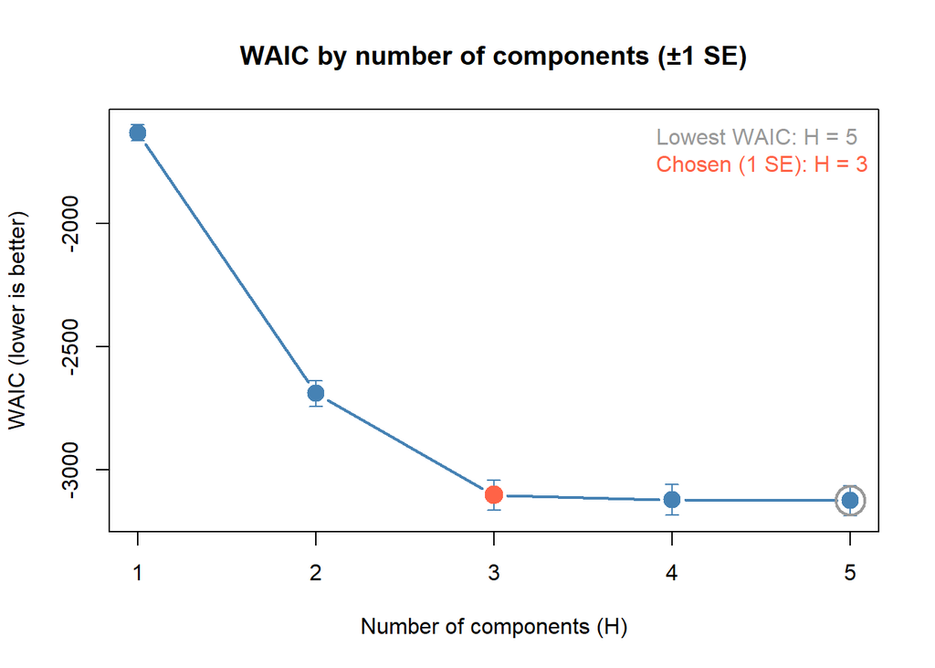

```r
# Define dynamic y-axis limits incorporating standard errors
ylim_waic <- range(c(all_waic_values - waic_se, all_waic_values + waic_se))

# Plot WAIC scores across model configurations
plot(1:5, all_waic_values,
     type = "b", pch = 19, cex = 1.5, col = "steelblue", lwd = 2,
     ylim = ylim_waic,
     xlab = "Number of components (H)",
     ylab = "WAIC (lower is better)",
     main = "WAIC by number of components (±1 SE)",
     xaxt = "n")
axis(1, at = 1:5)

# Add +/-1 SE error bars to represent estimate uncertainty
arrows(1:5, all_waic_values - waic_se, 1:5, all_waic_values + waic_se,
       angle = 90, code = 3, length = 0.05, col = "steelblue")

# Highlight absolute best configuration vs selected parsimonious model
lowest_H <- which.min(all_waic_values)
best_H   <- select_parsimonious(all_waic_values, waic_se, complexity = 1:5)
points(lowest_H, all_waic_values[lowest_H], col = "gray60", pch = 1, cex = 3, lwd = 2)
points(best_H,   all_waic_values[best_H],   col = "tomato", pch = 19, cex = 1.8)

legend("topright",
       legend = c(paste("Lowest WAIC: H =", lowest_H),
                  paste("Chosen (1 SE): H =", best_H)),
       text.col = c("gray60", "tomato"), bty = "n")
```

The following plots compare the empirical distribution of the load factor against the implied predictive mixture density for each evaluated complexity ($H=1$ to $5$).

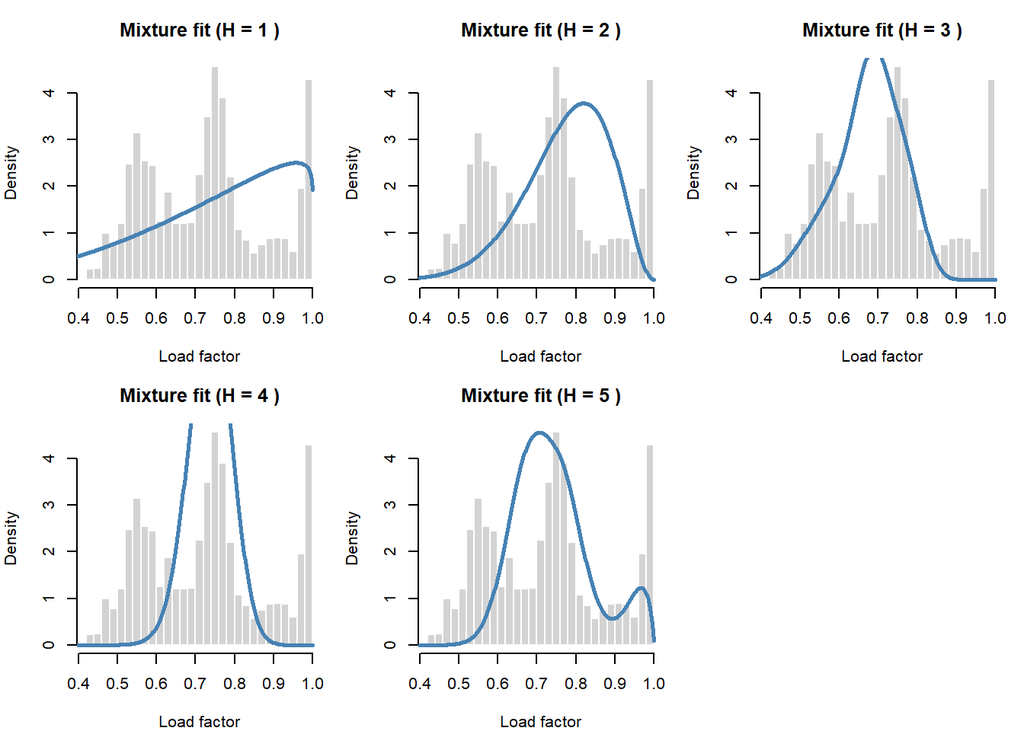

```r
# Set up grid for side-by-side model comparison plots
par(mfrow = c(2, 3), mar = c(4, 4, 3, 1))

x_seq <- seq(0.001, 0.999, length.out = 500)

for (h in 1:5) {
  # Extract posterior expectations for weights and Beta parameters
  current_samples <- all_samples[[h]]

  if (h == 1) {
    est_pi    <- 1
    est_alpha <- mean(current_samples$alpha)
    est_beta  <- mean(current_samples$beta)
  } else {
    est_pi    <- apply(current_samples$pi_weights, 1, mean)
    est_alpha <- apply(current_samples$alpha, 1, mean)
    est_beta  <- apply(current_samples$beta, 1, mean)
  }

  # Draw baseline empirical distribution
  hist(my_data, breaks = 30, freq = FALSE,
       col = "lightgray", border = "white",
       xlab = "Load factor", main = paste("Mixture fit (H =", h, ")"))

  # Compute and overlay the implied predictive mixture density
  total_density <- rep(0, 500)
  for (c in 1:h) {
    total_density <- total_density + est_pi[c] * dbeta(x_seq, est_alpha[c], est_beta[c])
  }
  lines(x_seq, total_density, col = "steelblue", lwd = 2.5)
}

# Restore default single-plot layout
par(mfrow = c(1, 1))
```

The plot below illustrates the selected Beta mixture model overlaid on the empirical data. Alongside the overall mixture density (solid line), we visualize the individual, weighted Beta components (dashed lines). This explicitly shows how the different latent regimes combine to form the overall distribution of the data.

```r
# Extract samples of the winning model
best_samples <- all_samples[[best_H]]

if (best_H == 1) {
  best_pi    <- 1
  best_alpha <- mean(best_samples$alpha)
  best_beta  <- mean(best_samples$beta)
} else {
  best_pi    <- apply(best_samples$pi_weights, 1, mean)
  best_alpha <- apply(best_samples$alpha, 1, mean)
  best_beta  <- apply(best_samples$beta, 1, mean)
}

# Print the final parameters to the console
cat("\nPosterior means of the best model (H =", best_H, ")\n")
```

```
##
## Posterior means of the best model (H = 3 )
```

```r
final_params <- data.frame(Component = 1:best_H, Weight_Pi = best_pi, Alpha = best_alpha, Beta = best_beta)
print(round(final_params, 3))
```

```
##   Component Weight_Pi  Alpha   Beta
## 1         1     0.317 25.595 17.858
## 2         2     0.315 54.647 17.779
## 3         3     0.368 72.919 34.401
```

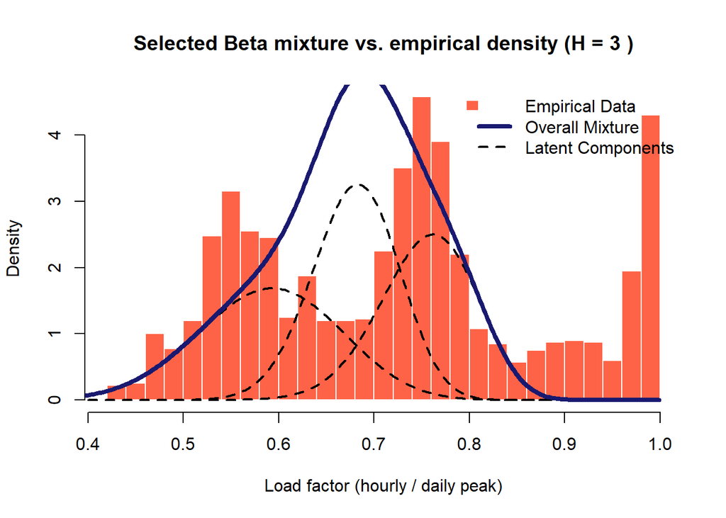

```r
# Plot empirical distribution for the selected optimal model
hist(my_data, breaks = 40, freq = FALSE,
     col = "tomato", border = "white",
     xlab = "Load factor (hourly / daily peak)",
     main = paste("Selected Beta mixture vs. empirical density (H =", best_H, ")"))

# Calculate total mixture density and overlay constituent latent distributions
total_density <- rep(0, 500)

for (c in 1:best_H) {
  # Scale individual Beta component density by its posterior weight
  comp_density  <- best_pi[c] * dbeta(x_seq, best_alpha[c], best_beta[c])
  total_density <- total_density + comp_density

  # Overlay individual latent component profiles
  if (best_H > 1) {
    lines(x_seq, comp_density, col = "black", lty = 2, lwd = 2)
  }
}

# Draw the combined mixture density profile
lines(x_seq, total_density, col = "midnightblue", lwd = 4)

if (best_H > 1) {
  legend("topright",
         legend = c("Empirical Data", "Overall Mixture", "Latent Components"),
         fill = c("tomato", NA, NA),
         border = c("white", NA, NA),
         col = c(NA, "midnightblue", "black"),
         lty = c(NA, 1, 2),
         lwd = c(NA, 4, 2),
         bty = "n")
}
```

Although this $H$ was selected as the best model, the individual component curves above look implausible. This is not a failure of the fit but an artefact of how the curves were built. Each component was drawn using parameters averaged across all MCMC draws, and in a mixture the component labels are not identifiable: the sampler is free to permute them from one iteration to the next (*label switching*). The next section diagnoses this phenomenon and then resolves it with a post-hoc relabelling.

## MCMC Diagnostics

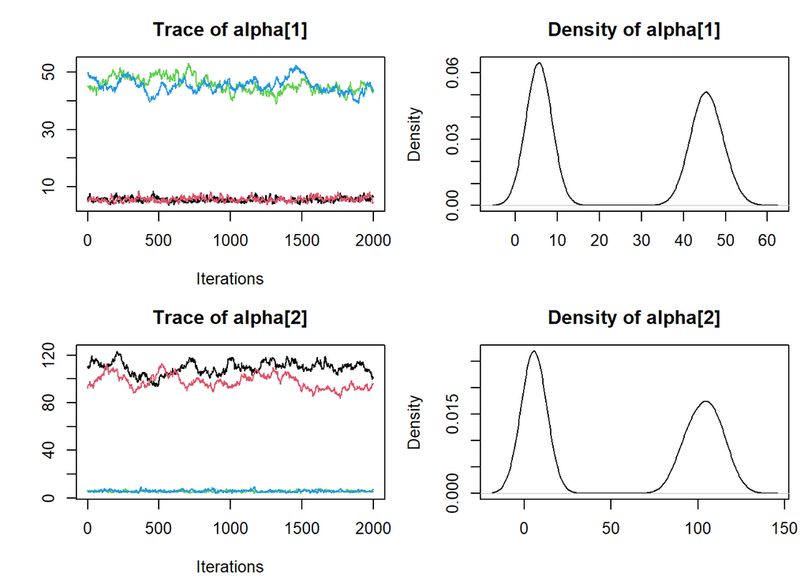

```r
raw_samples <- all_samples[[best_H]]

raw_pi_mat    <- matrix(raw_samples$pi_weights, nrow = best_H)
raw_alpha_mat <- matrix(raw_samples$alpha, nrow = best_H)
raw_beta_mat  <- matrix(raw_samples$beta, nrow = best_H)

alpha_array <- raw_samples$alpha
beta_array  <- raw_samples$beta
pi_array <- raw_samples$pi_weights

n_iter   <- dim(alpha_array)[2]
n_chains <- dim(alpha_array)[3]

chain_colors <- 1:n_chains

# Diagnostics for alpha.
par(mfrow = c(2, 2), mar = c(4, 4, 3, 1))

for (h in 1:best_H) {
  y_lims <- range(alpha_array[h, , ])

  plot(1:n_iter, alpha_array[h, , 1], type = "l", col = chain_colors[1],
       ylim = y_lims, xlab = "Iterations", ylab = "",
       main = paste0("Trace of alpha[", h, "]"))

  if (n_chains > 1) {
    for (c in 2:n_chains) {
      lines(1:n_iter, alpha_array[h, , c], col = chain_colors[c])
    }
  }

  plot(density(raw_alpha_mat[h, ]),
       main = paste0("Density of alpha[", h, "]"),
       xlab = "", ylab = "Density")
}
```

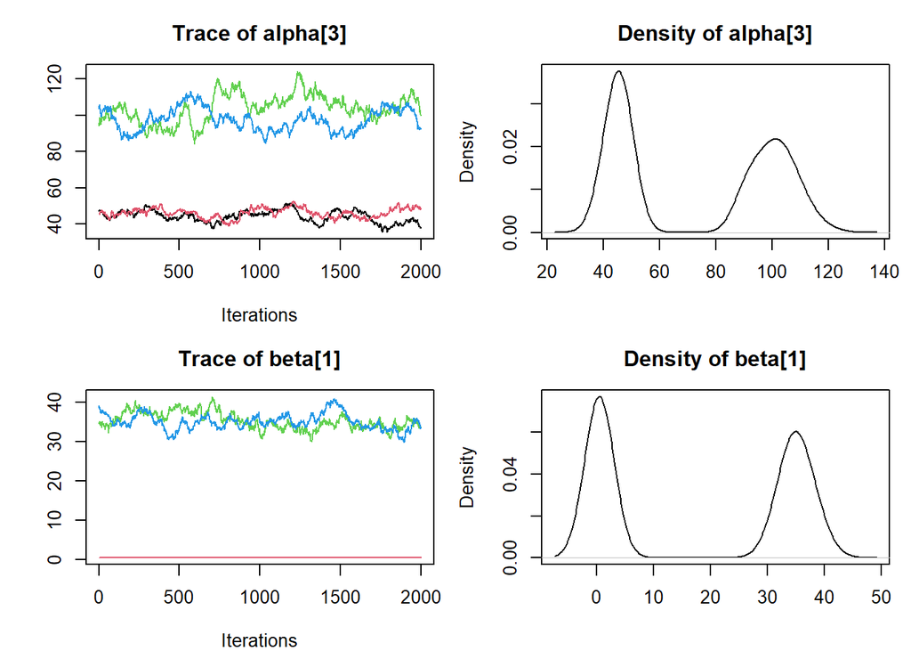

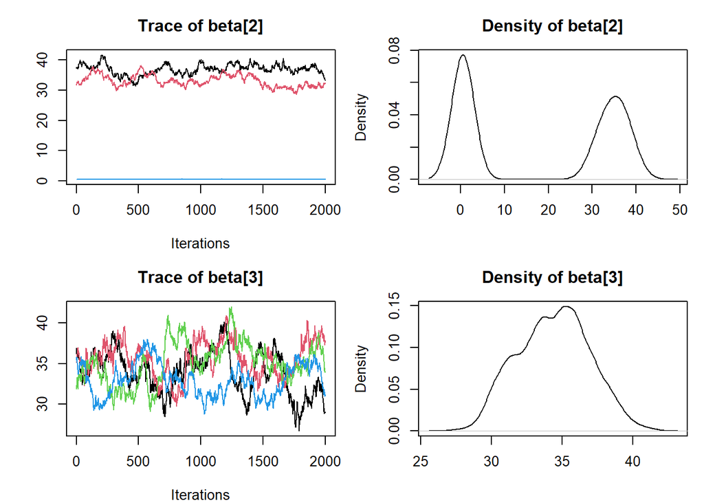

```r
# Diagnostics for beta.
for (h in 1:best_H) {
  y_lims <- range(beta_array[h, , ])

  plot(1:n_iter, beta_array[h, , 1], type = "l", col = chain_colors[1],
       ylim = y_lims, xlab = "Iterations", ylab = "",
       main = paste0("Trace of beta[", h, "]"))

  if (n_chains > 1) {
    for (c in 2:n_chains) {
      lines(1:n_iter, beta_array[h, , c], col = chain_colors[c])
    }
  }

  plot(density(raw_beta_mat[h, ]),
       main = paste0("Density of beta[", h, "]"),
       xlab = "", ylab = "Density")
}
```

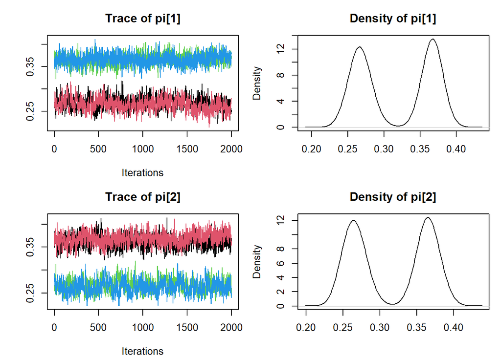

```r
# Diagnostics for pi.
for (h in 1:best_H) {
  y_lims <- range(pi_array[h, , ])

  plot(1:n_iter, pi_array[h, , 1], type = "l", col = chain_colors[1],
       ylim = y_lims, xlab = "Iterations", ylab = "",
       main = paste0("Trace of pi[", h, "]"))

  if (n_chains > 1) {
    for (c in 2:n_chains) {
      lines(1:n_iter, pi_array[h, , c], col = chain_colors[c])
    }
  }

  plot(density(raw_pi_mat[h, ]),
       main = paste0("Density of pi[", h, "]"),
       xlab = "", ylab = "Density")
}
```

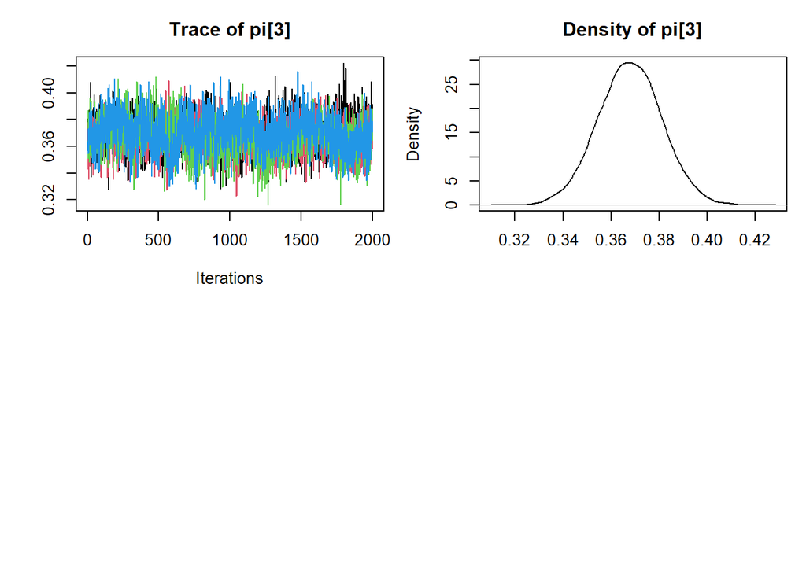

```r
par(mfrow = c(1, 1))
```

Now we calculate Gelman-Rubin coefficient, $\hat{R}$ :

```r
calculate_rhat_table <- function(alpha_array, beta_array, pi_array, best_H, n_chains) {

  # Vectors to store the point estimates
  rhat_alpha <- numeric(best_H)
  rhat_beta  <- numeric(best_H)
  rhat_pi    <- numeric(best_H)

  for (h in 1:best_H) {
    # Gelman-Rubin Diagnostic for Alpha
    chain_list_alpha <- list()
    for (c in 1:n_chains) {
      chain_list_alpha[[c]] <- mcmc(alpha_array[h, , c])
    }
    gr_alpha <- gelman.diag(as.mcmc.list(chain_list_alpha), autoburnin = FALSE)
    rhat_alpha[h] <- gr_alpha$psrf[1, 1] # Extract Point Estimate

    # For Beta
    chain_list_beta <- list()
    for (c in 1:n_chains) {
      chain_list_beta[[c]] <- mcmc(beta_array[h, , c])
    }
    gr_beta <- gelman.diag(as.mcmc.list(chain_list_beta), autoburnin = FALSE)
    rhat_beta[h] <- gr_beta$psrf[1, 1] # Extract Point Estimate

    # For Pi
    chain_list_pi <- list()
    for (c in 1:n_chains) {
      chain_list_pi[[c]] <- mcmc(pi_array[h, , c])
    }
    gr_pi <- gelman.diag(as.mcmc.list(chain_list_pi), autoburnin = FALSE)
    rhat_pi[h] <- gr_pi$psrf[1, 1] # Extract Point Estimate
  }

  # Generate variable names dynamically
  alpha_names <- paste0("alpha[", 1:best_H, "]")
  beta_names  <- paste0("beta[", 1:best_H, "]")
  pi_names    <- paste0("pi[", 1:best_H, "]")

  # Assemble diagnostics into a single dataframe for presentation
  rhat_table <- data.frame(
    Variable = c(alpha_names, beta_names, pi_names),
    Raw_R_hat = round(c(rhat_alpha, rhat_beta, rhat_pi), 4)
  )

  return(rhat_table)
}

# Evaluate convergence using the 3D raw sample arrays from JAGS
rhat_table_output <- calculate_rhat_table(raw_samples$alpha,
                                          raw_samples$beta,
                                          raw_samples$pi_weights,
                                          best_H,
                                          n_chains)

print(rhat_table_output, row.names = FALSE)
```

```
##  Variable Raw_R_hat
##  alpha[1]   17.2157
##  alpha[2]   19.6549
##  alpha[3]    8.2966
##   beta[1]   18.8681
##   beta[2]   20.7348
##   beta[3]    1.1668
##     pi[1]    5.9261
##     pi[2]    5.7758
##     pi[3]    1.0233
```

At this point two explanations are possible:

- the chains genuinely failed to mix and explore the posterior
- the high $\hat{R}$ is a statistical artifact caused by the chains sampling from different, but equivalent, label permutations of a well-mixed sampler.

To distinguish between the two explanations, we evaluate $\hat{R}$ and the Effective Sample Size (ESS) on the **marginal log-likelihood** $\ell^{(s)} = \sum_{i=1}^N \log p(x_i \mid \boldsymbol{\theta}^{(s)})$. This scalar is a function of the full mixture density, which is invariant to any relabelling of the components, so it is unaffected by label switching.

```r
loglik_array <- raw_samples$log_lik

n_iter   <- dim(loglik_array)[2]
n_chains <- dim(loglik_array)[3]

# Marginalize out component labels by summing point-wise log-likelihoods
global_loglik <- apply(loglik_array, c(2, 3), sum)

# Format global log-likelihood iterations into an mcmc.list object
loglik_chains <- list()
for (c in 1:n_chains) {
  loglik_chains[[c]] <- mcmc(global_loglik[, c])
}
loglik_mcmc_list <- as.mcmc.list(loglik_chains)

# Compute permutation-invariant convergence statistics
rhat_loglik <- gelman.diag(loglik_mcmc_list, autoburnin = FALSE)$psrf[1, 1]
ess_loglik  <- effectiveSize(loglik_mcmc_list)

# Assemble diagnostics table
likelihood_diagnostic_table <- data.frame(
  Metric = c("R-hat ", "ESS  "),
  Value  = c(round(rhat_loglik, 4), round(ess_loglik, 2))
)

cat("Likelihood Convergence Diagnostic (Permutation-Invariant Scale)\n\n")
```

```
## Likelihood Convergence Diagnostic (Permutation-Invariant Scale)
```

```r
print(likelihood_diagnostic_table, row.names = FALSE)
```

```
##  Metric    Value
##  R-hat    1.0446
##   ESS   518.6700
```

The table above shows $\hat{R} \approx 1$ and a healthy ESS, confirming that the sampler has reached global convergence. The instability in the raw component parameters is therefore purely an artifact of the chains sampling from different label permutations of the same posterior mode.

## **Post-hoc re-labelling**

To restore parameter identifiability for reporting, we apply a **post-hoc re-labelling**: at each MCMC draw we sort the $H$ components by their theoretical Beta mean,

$$\mathbb{E}[X_h] =
\frac{\alpha_h}{\alpha_h + \beta_h},$$

from smallest to largest. This post-hoc step does not alter the fit: the mixture density and the WAIC are unchanged; it only resolves the label ambiguity for interpretation.

```r
best_samples <- all_samples[[best_H]]

# Reorder every draw by ascending Beta mean so component labels are consistent
ord      <- reorder_draws_by_mean(best_samples, best_H)
S_tot <- ncol(ord$pi)
x_seq    <- seq(0.001, 0.999, length.out = 500)

component_curves <- array(0, dim = c(best_H, S_tot, length(x_seq)))

cat("Sorting MCMC chains and calculating posterior densities...\n")
```

```
## Sorting MCMC chains and calculating posterior densities...
```

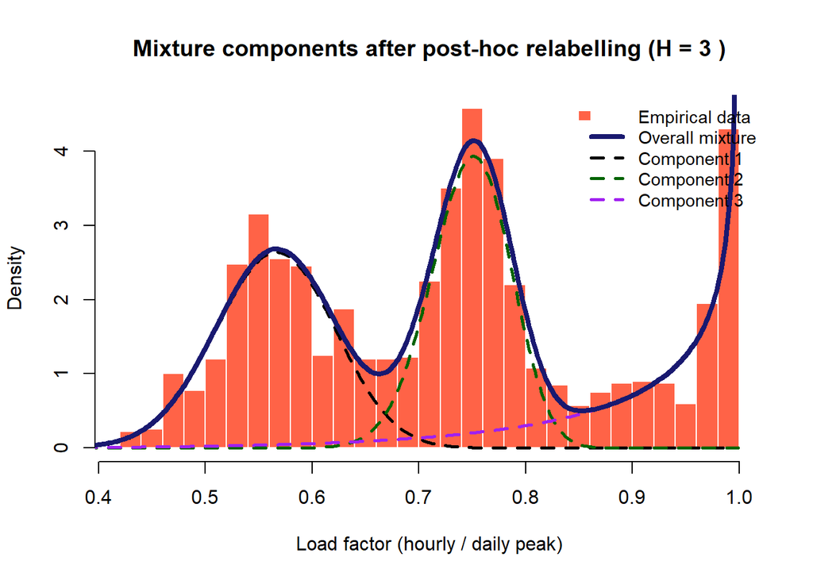

```r
for (s in 1:S_tot) {
  for (h in 1:best_H) {
    component_curves[h, s, ] <- ord$pi[h, s] *
      dbeta(x_seq, ord$alpha[h, s], ord$beta[h, s])
  }
}

# Average curves over iterations to obtain point estimates of latent profiles
final_components      <- apply(component_curves, c(1, 3), mean)
final_overall_mixture <- colSums(final_components)

# PLOTTING

hist(my_data, breaks = 40, freq = FALSE,
     col = "tomato", border = "white",
     xlab = "Load factor (hourly / daily peak)",
     main = paste("Mixture components after post-hoc relabelling (H =", best_H, ")"))

# Overlay identified, sorted latent components
for (h in 1:best_H) {
  lines(x_seq, final_components[h, ], col = COMPONENT_COLS[h], lty = 2, lwd = 2.5)
}

# Overlay final posterior predictive mixture profile
lines(x_seq, final_overall_mixture, col = "midnightblue", lwd = 4)

legend_labels <- c("Empirical data", "Overall mixture", paste("Component", 1:best_H))
legend_colors <- c(NA, "midnightblue", COMPONENT_COLS[1:best_H])
legend_lines  <- c(NA, 1, rep(2, best_H))
legend_widths <- c(NA, 4, rep(2.5, best_H))

legend("topright",
       legend = legend_labels,
       fill = c("tomato", rep(NA, best_H + 1)),
       border = c("white", rep(NA, best_H + 1)),
       col = legend_colors,
       lty = legend_lines,
       lwd = legend_widths,
       bty = "n",
       cex = 0.9)
```

Below, we visualize each sorted component independently, alongside its expected weight, shape parameters ($\alpha$, $\beta$), and theoretical mean. Furthermore, we compute the 95% equal-tailed **credible intervals** for the parameters, providing a rigorous quantification of the posterior uncertainty for each identified cluster within the data.

```r
best_samples <- all_samples[[best_H]]

# Reorder MCMC draws post-hoc by ascending component means to resolve label switching
ord       <- reorder_draws_by_mean(best_samples, best_H)
pi_ord    <- ord$pi
alpha_ord <- ord$alpha
beta_ord  <- ord$beta

# Helper to compute posterior expectations and 95% equal-tailed credible intervals
summ <- function(m) cbind(mean = rowMeans(m),
                          lwr  = apply(m, 1, quantile, 0.025),
                          upr  = apply(m, 1, quantile, 0.975))
A <- summ(alpha_ord); B <- summ(beta_ord); P <- summ(pi_ord)
comp_mean <- A[, "mean"] / (A[, "mean"] + B[, "mean"])

# Generate summary table for the identified mixture components
tab <- data.frame(
  Component = 1:best_H,
  Weight    = round(P[, "mean"], 3),
  Alpha     = round(A[, "mean"], 3),
  Beta      = round(B[, "mean"], 3),
  Mean      = round(comp_mean, 3),
  Alpha_CI  = paste0("[", round(A[, "lwr"], 2), ", ", round(A[, "upr"], 2), "]"),
  Beta_CI   = paste0("[", round(B[, "lwr"], 2), ", ", round(B[, "upr"], 2), "]")
)
cat("Component parameters (posterior mean, 95% credible interval)\n")
```

```
## Component parameters (posterior mean, 95% credible interval)
```

```r
print(tab, row.names = FALSE)
```

```
##  Component Weight   Alpha   Beta  Mean       Alpha_CI        Beta_CI
##          1  0.367  45.382 34.967 0.565 [39.39, 50.79] [30.14, 39.33]
##          2  0.367 102.171 34.531 0.747 [88.4, 117.13]    [30, 39.44]
##          3  0.266   5.608  0.540 0.912   [4.28, 7.39]    [0.49, 0.6]
```

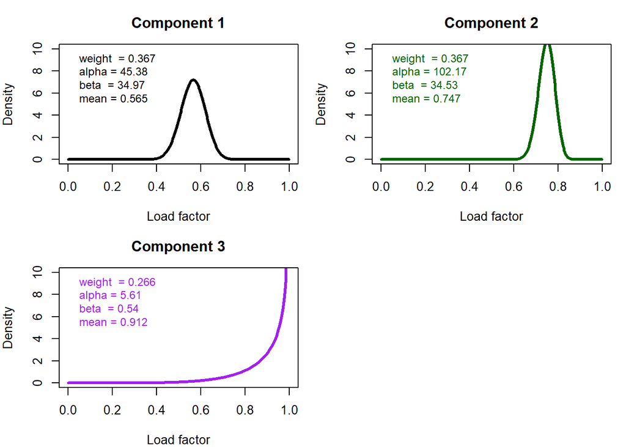

```r
x_seq <- seq(0.001, 0.999, length.out = 500)

# Evaluate densities using posterior parameter expectations
dens_mat <- sapply(1:best_H, function(h) dbeta(x_seq, A[h, "mean"], B[h, "mean"]))

ylim_common <- c(0, 10)
xlim_common <- c(0, 1)

# Plot individual component profiles in a multi-figure layout
par(mfrow = c(ceiling(best_H / 2), 2), mar = c(4, 4, 3, 1))
for (h in 1:best_H) {
  plot(x_seq, dens_mat[, h], type = "l", lwd = 3, col = COMPONENT_COLS[h],
       xlim = xlim_common, ylim = ylim_common,
       xlab = "Load factor", ylab = "Density",
       main = paste("Component", h))
  legend("topleft", bty = "n", cex = 0.9, text.col = COMPONENT_COLS[h],
         legend = c(sprintf("weight  = %.3f", P[h, "mean"]),
                    sprintf("alpha = %.2f", A[h, "mean"]),
                    sprintf("beta  = %.2f", B[h, "mean"]),
                    sprintf("mean = %.3f", comp_mean[h])))
}
par(mfrow = c(1, 1))
```

# Prior Sensitivity Analysis

The mixture model relies on two main hyperparameters: the rate $\lambda$ (for the Exponential prior on the shape parameters $\alpha_h$ and $\beta_h$) and the concentration $c$ (for the Dirichlet prior on the mixture weights $\boldsymbol{\pi}$).

To make sure these choices aren’t secretly running the show, we run a sensitivity analysis. Essentially, we check if changing these priors drastically alters our key results. If results are stable across settings the inference is data-driven; if they shift, the prior is influential and the choice requires more careful justification.

We refit the best-$H$ model under four configurations, varying one hyperparameter at a time while holding the rest fixed:

| Setting | $\lambda$ | Dir. conc. $c$ | Interpretation |
| --- | --- | --- | --- |
| Reference | 0.10 | 1.0 | Current prior: $\mathbb{E}[\alpha_h] = 10$ |
| Very diffuse | 0.01 | 1.0 | Shape parameters up to $\sim\!200$ allowed |
| Informative | 1.00 | 1.0 | Shape parameters concentrated near 1 |
| Sparse Dirichlet | 0.10 | 0.1 | Encourages one dominant component |

```r
# Parameterised JAGS model
jags_model_sens <- "
model {
  for (i in 1:N) {
    z[i] ~ dcat(pi_weights[1:H])
    x[i] ~ dbeta(alpha[z[i]], beta[z[i]])
    for (h in 1:H) {
      lcomp[i, h] <- log(pi_weights[h]) + logdensity.beta(x[i], alpha[h], beta[h])
    }
    mx[i]      <- max(lcomp[i, 1:H])
    for (h in 1:H) { e[i, h] <- exp(lcomp[i, h] - mx[i]) }
    log_lik[i] <- mx[i] + log(sum(e[i, 1:H]))
  }
  pi_weights[1:H] ~ ddirch(dir_conc[1:H])
  for (h in 1:H) {
    alpha[h] ~ dexp(lambda_exp)
    beta[h]  ~ dexp(lambda_exp)
  }
}
"

# Helper: fit best_H model with given hyperparameters
fit_sensitivity <- function(H, lambda_exp, dir_conc_val) {
  dat <- list(x          = my_data,
              N          = N,
              H          = H,
              lambda_exp = lambda_exp,
              dir_conc   = rep(dir_conc_val, H))
  m <- jags.model(textConnection(jags_model_sens), data = dat,
                  inits = make_inits(N_CHAINS), n.chains = N_CHAINS, quiet = TRUE)
  update(m, n.iter = N_BURNIN)
  jags.samples(m, variable.names = c("pi_weights", "alpha", "beta", "log_lik"),
               n.iter = N_SAMPLES)
}

# Helper: label-switching-invariant posterior predictive density
compute_ppd_sens <- function(samps, H, x_grid) {
  pi_m <- matrix(samps$pi_weights, nrow = H)
  al_m <- matrix(samps$alpha,      nrow = H)
  be_m <- matrix(samps$beta,       nrow = H)
  S    <- ncol(pi_m)
  rowMeans(sapply(seq_len(S), function(s) {
    d <- numeric(length(x_grid))
    for (h in seq_len(H))
      d <- d + pi_m[h, s] * dbeta(x_grid, al_m[h, s], be_m[h, s])
    d
  }))
}
```

```r
sens_settings <- list(
  list(label = "Reference (λ=0.1, c=1.0)",     lambda = 0.10, dir = 1.0),
  list(label = "Very diffuse (λ=0.01, c=1.0)", lambda = 0.01, dir = 1.0),
  list(label = "Informative (λ=1.0, c=1.0)",   lambda = 1.00, dir = 1.0),
  list(label = "Sparse Dir. (λ=0.1, c=0.1)",   lambda = 0.10, dir = 0.1)
)

# Setting 1 is already fitted as best_H in Task 1 — reuse it directly.
# Settings 2-4 are refitted with the parameterised model above.
sens_samples <- vector("list", length(sens_settings))
sens_samples[[1]] <- all_samples[[best_H]]

for (j in 2:length(sens_settings)) {
  s <- sens_settings[[j]]
  cat("Sensitivity fit:", s$label, "\n")
  sens_samples[[j]] <- fit_sensitivity(best_H, s$lambda, s$dir)
}
```

```
## Sensitivity fit: Very diffuse (λ=0.01, c=1.0)
## Sensitivity fit: Informative (λ=1.0, c=1.0)
## Sensitivity fit: Sparse Dir. (λ=0.1, c=0.1)
```

```r
# WAIC comparison table across prior settings
sens_waic_objs <- lapply(sens_samples, function(sf)
  waic_from_loglik(sf$log_lik))

sens_table <- do.call(rbind, Map(function(w, nm) ic_row(w, nm),
                                 sens_waic_objs,
                                 sapply(sens_settings, `[[`, "label")))
cat("\nPrior sensitivity: WAIC for H =", best_H, "\n")
```

```
##
## Prior sensitivity: WAIC for H = 3
```

```r
print(sens_table, row.names = FALSE)
```

```
##                         Model   ELPD p_eff    WAIC   SE
##      Reference (λ=0.1, c=1.0) 1550.4   6.4 -3100.9 60.7
##  Very diffuse (λ=0.01, c=1.0) 1550.4   7.5 -3100.9 61.8
##    Informative (λ=1.0, c=1.0) 1342.6   3.4 -2685.2 50.4
##    Sparse Dir. (λ=0.1, c=0.1) 1533.0  21.8 -3066.1 59.0
```

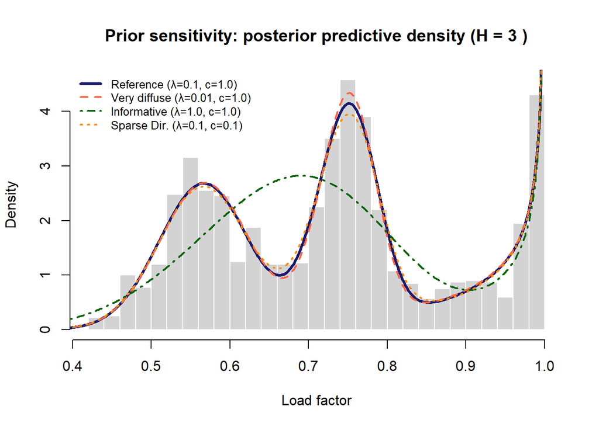

```r
# Overlay the posterior predictive density for each prior setting.
# no re-ordering is needed here.
x_grid_s  <- seq(0.001, 0.999, length.out = 500)
sens_cols  <- c("midnightblue", "tomato", "darkgreen", "darkorange")
sens_ltys  <- c(1, 2, 4, 3)
sens_lwds  <- c(3, 2, 2, 2)

ppd_list <- lapply(sens_samples, function(sf)
  compute_ppd_sens(sf, best_H, x_grid_s))

hist(my_data, breaks = 40, freq = FALSE,
     col = "lightgray", border = "white",
     xlab = "Load factor",
     main = paste("Prior sensitivity: posterior predictive density (H =", best_H, ")"))

for (j in seq_along(sens_settings)) {
  lines(x_grid_s, ppd_list[[j]],
        col  = sens_cols[j],
        lwd  = sens_lwds[j],
        lty  = sens_ltys[j])
}

legend("topleft",
       legend = sapply(sens_settings, `[[`, "label"),
       col = sens_cols, lwd = sens_lwds, lty = sens_ltys,
       bty = "n", cex = 0.8)
```

# Task 2

Objective: overlay the **posterior predictive density** on the empirical histogram and verify that the modes (the peaks of the data) are recovered by the model selected in Task 1.

## Posterior predictive density

The fully Bayesian overlay is the **posterior predictive density**, obtained by averaging the mixture density over the *entire* posterior:
$$p(\tilde x \mid
\text{data})
= \frac{1}{S}\sum_{s=1}^S \sum_{h=1}^H
\pi_h^{(s)}\,\text{Beta}\!\left(\tilde x \mid \alpha_h^{(s)},
\beta_h^{(s)}\right).$$

We average the **densities**, not the parameters. This way the curve accounts for posterior uncertainty.

```r
best_samples <- all_samples[[best_H]]
x_grid <- seq(0.001, 0.999, length.out = 600)

if (best_H == 1) {
  alpha_s <- as.vector(best_samples$alpha)
  beta_s  <- as.vector(best_samples$beta)
  S_tot   <- length(alpha_s)
  ppd     <- rowMeans(sapply(seq_len(S_tot),
                             function(s) dbeta(x_grid, alpha_s[s], beta_s[s])))
} else {
  pi_mat    <- matrix(best_samples$pi_weights, nrow = best_H)
  alpha_mat <- matrix(best_samples$alpha,      nrow = best_H)
  beta_mat  <- matrix(best_samples$beta,       nrow = best_H)
  S_tot     <- ncol(pi_mat)

  # full mixture density for a single draw s
  mix_density <- function(s) {
    d <- numeric(length(x_grid))
    for (h in 1:best_H)
      d <- d + pi_mat[h, s] * dbeta(x_grid, alpha_mat[h, s], beta_mat[h, s])
    d
  }
  # posterior predictive = average over all draws
  ppd <- rowMeans(sapply(seq_len(S_tot), mix_density))
}
```

## Overlay and mode recovery

```r
# A point is a local maximum if it exceeds both its neighbours
local_maxima <- function(xx, yy) {
  n   <- length(yy)
  hit <- which(yy[2:(n - 1)] > yy[1:(n - 2)] & yy[2:(n - 1)] > yy[3:n]) + 1
  xx[hit]
}

ppd_modes <- local_maxima(x_grid, ppd)
cat("Posterior-predictive modes: ", round(ppd_modes, 3), "\n")
```

```
## Posterior-predictive modes:  0.567 0.751
```

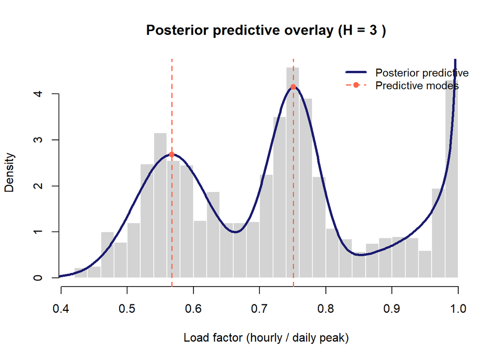

```r
hist(my_data, breaks = 40, freq = FALSE,
     col = "lightgray", border = "white",
     xlab = "Load factor (hourly / daily peak)",
     main = paste("Posterior predictive overlay (H =", best_H, ")"))
lines(x_grid, ppd, col = "midnightblue", lwd = 3)

abline(v = ppd_modes, col = "tomato", lty = 2, lwd = 1.5)
points(ppd_modes, approx(x_grid, ppd, ppd_modes)$y, pch = 19, col = "tomato")

legend("topright", bty = "n", cex = 0.9,
       legend = c("Posterior predictive", "Predictive modes"),
       col = c("midnightblue", "tomato"),
       lty = c(1, 2), lwd = c(3, 1.5), pch = c(NA, 19))
```

# Task 3

Objective (**post-hoc exploration**): assign each observation to its maximum-a-posteriori (MAP) component, then plot the empirical fraction of observations in each component as a function of `hour`.

We compute **posterior responsibilities** using the components **re-ordered by their mean** at every draw (the same ordering used in the plots above):
$$r_{ih} = \frac{1}{S}\sum_{s=1}^S
\frac{\pi^{(s)}_{(h)}\,\text{Beta}(x_i\mid\alpha^{(s)}_{(h)},\beta^{(s)}_{(h)})}{\sum_k
\pi^{(s)}_{(k)}\,\text{Beta}(x_i\mid\alpha^{(s)}_{(k)},\beta^{(s)}_{(k)})},
\qquad \hat z_i = \arg\max_h r_{ih},$$
where $(h)$ denotes the $h$-th component from the left (smallest mean).

```r
best_samples <- all_samples[[best_H]]

# Components sorted by increasing mean at every draw (component 1 = lowest mean)
ord   <- reorder_draws_by_mean(best_samples, best_H)
S_tot <- ncol(ord$pi)

# mean responsibilities: resp[i, h] = P(component h | x_i)
resp <- matrix(0, nrow = N, ncol = best_H)

for (s in 1:S_tot) {
  w <- matrix(0, nrow = N, ncol = best_H)
  for (h in 1:best_H) {
    w[, h] <- ord$pi[h, s] * dbeta(my_data, ord$alpha[h, s], ord$beta[h, s])
  }
  w <- w / rowSums(w)   # normalise -> responsibilities at this draw
  resp <- resp + w
}
resp <- resp / S_tot

# MAP assignment: each observation to its most probable component
z_map <- apply(resp, 1, which.max)

cat("Cluster sizes (MAP assignment):\n")
```

```
## Cluster sizes (MAP assignment):
```

```r
print(table(factor(z_map, levels = 1:best_H)))
```

```
##
##   1   2   3
## 755 784 461
```

Empirical fraction of observations in each component as a function of the hour of the day.

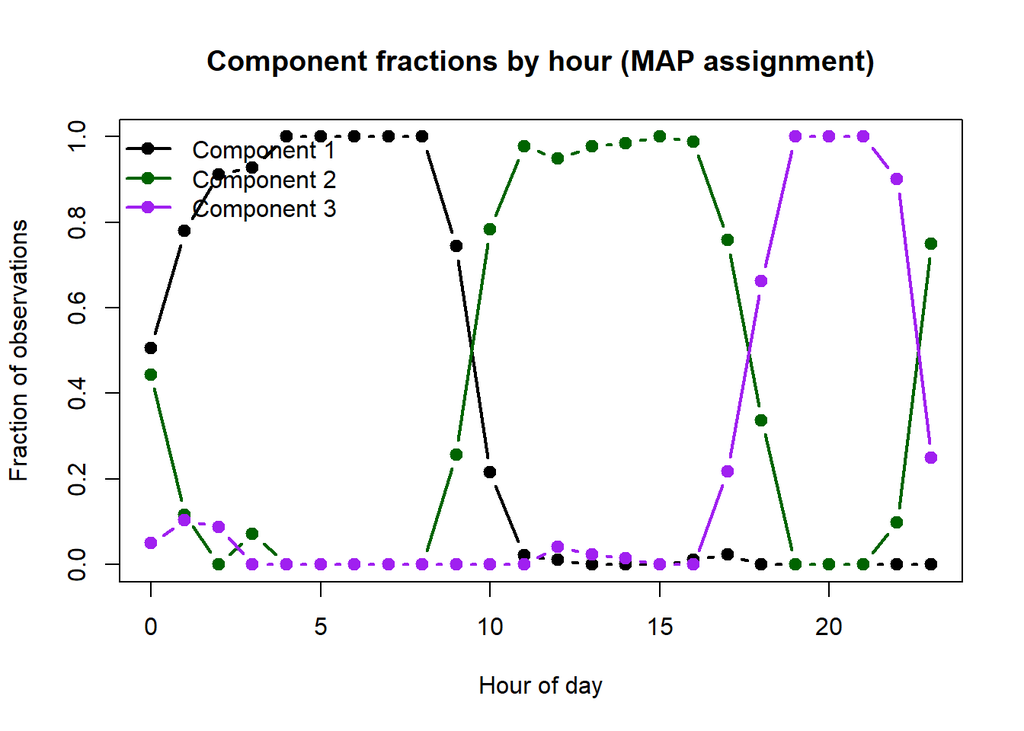

```r
hours <- lf_fit$hour

# hour x component contingency table, then row-proportions (each hour sums to 1)
tab      <- table(factor(hours, levels = 0:23), factor(z_map, levels = 1:best_H))
frac_mat <- prop.table(tab, margin = 1)

matplot(0:23, as.matrix(frac_mat), type = "b", pch = 19, lty = 1,
        col = COMPONENT_COLS[1:best_H], lwd = 2,
        xlab = "Hour of day",
        ylab = "Fraction of observations",
        main = "Component fractions by hour (MAP assignment)")
legend("topleft", legend = paste("Component", 1:best_H),
       col = COMPONENT_COLS[1:best_H], lwd = 2, pch = 19, bty = "n")
```

A complementary view: raw observations coloured by their MAP component, plotted against hour.

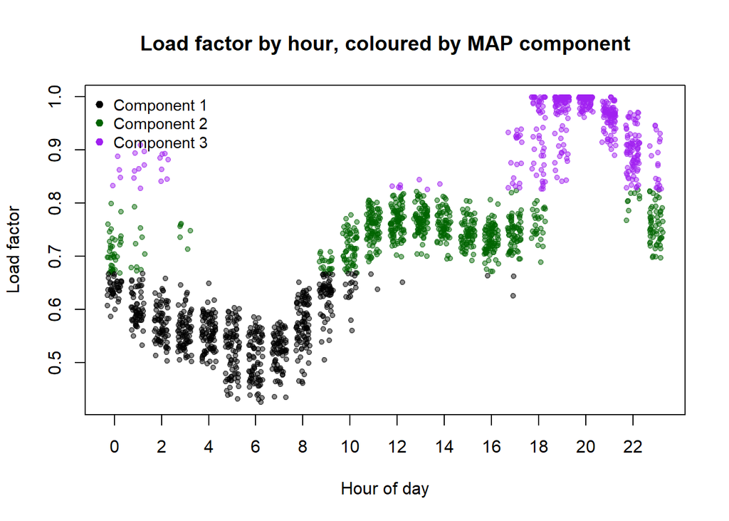

```r
plot(jitter(hours, amount = 0.3), my_data,
     col  = adjustcolor(COMPONENT_COLS[z_map], alpha.f = 0.45),
     pch  = 19, cex = 0.7,
     xlab = "Hour of day", ylab = "Load factor",
     main = "Load factor by hour, coloured by MAP component",
     xaxt = "n")
axis(1, at = seq(0, 23, by = 2))
legend("topleft", legend = paste("Component", 1:best_H),
       col = COMPONENT_COLS[1:best_H], pch = 19, bty = "n", cex = 0.9)
```

# Task 4

Objective (**advanced**): fit a second model that performs *classification on `hour`*, using the component assignment from Task 3 as the **response variable**, and plot the predicted probability of each component as a function of `hour`. We then compare these predicted curves with the empirical fractions of Task 3 and discuss the result.

## From clustering to a supervised model on `hour`

We model the predictability of the latent labels $\hat z_i \in \{1, \dots, H\}$ (obtained from Task 3) using the time of day as the sole covariate. Since $H > 2$, we implement a multinomial logistic regression, setting component $h = 1$ (lowest-mean) as the reference category.

## Mathematical formulation

For observation $i$ and component $h$ the linear predictor is
$$\eta_{i,h} = \beta_{0,h} +
\sum_{k=1}^{K}\bigl(\alpha_{k,h}\,s_{ik}
+ \gamma_{k,h}\,c_{ik}\bigr),$$
with the reference class constrained to zero, $\beta_{0,1} = 0$ and $\alpha_{k,1} = \gamma_{k,1} = 0$ for all $k$.

The class probabilities are recovered with the **softmax** transform
$$P(z_i =
h) =
\frac{\exp(\eta_{i,h})}{\sum_{j=1}^{H}\exp(\eta_{i,j})},$$

We place independent, weakly informative $\mathcal{N}(0, 0.01)$ priors (JAGS precision parameterization, variance $= 100$) on all free coefficients.

## Design matrices and JAGS model

We pre-compute the sine/cosine matrices $S$ and $C$ in R and pass them to JAGS as data; the response is `z_map` from Task 3 and the covariate is `hours`. The JAGS code is the categorical-logit skeleton: `z[i] ~ dcat(pp[i, 1:H])` with `pp[i, ]` built from the softmax of the Fourier linear predictors. To perform model selection for $K$ via WAIC, we monitor the marginal per-observation log-likelihood: `log_lik[i] = log(pp[i, z[i]])`.

```r
jags_model_logit <- "
model {
  for (i in 1:n) {
    z[i] ~ dcat(pp[i, 1:H])
    for (h in 1:H) {
      eta[i, h]    <- beta0[h] +
                      inprod(alpha[1:K, h], S[i, 1:K]) +
                      inprod(gamma[1:K, h], C[i, 1:K])
      expEta[i, h] <- exp(eta[i, h])
      pp[i, h]     <- expEta[i, h] / sum(expEta[i, 1:H])
    }
   log_lik[i] <- log(pp[i, z[i]])
  }

  beta0[1] <- 0
  for (k in 1:K) { alpha[k, 1] <- 0; gamma[k, 1] <- 0 }

  for (h in 2:H) {
    beta0[h] ~ dnorm(0, 0.01)
    for (k in 1:K) {
      alpha[k, h] ~ dnorm(0, 0.01)
      gamma[k, h] ~ dnorm(0, 0.01)
    }
  }
}
"
```

Helper that builds the Fourier design for a given number of harmonics $K$, fits the model and returns the monitored samples.

```r
# Reshape the monitored logit coefficients of one fit into per-draw arrays:
# beta0 as [H, S], alpha and gamma as [K, H, S].
reshape_logit_coefs <- function(fit, H, K) {
  beta0_s <- matrix(fit$beta0, nrow = H)
  S       <- ncol(beta0_s)
  list(beta0 = beta0_s,
       alpha = array(fit$alpha, dim = c(K, H, S)),
       gamma = array(fit$gamma, dim = c(K, H, S)))
}

# Posterior-mean class probabilities P(component | hour) for a Fourier design,
# averaging the softmax over all posterior draws (not the coefficients).
predict_logit_probs <- function(coefs, design, H) {
  n <- nrow(design$S)
  S <- ncol(coefs$beta0)
  P <- matrix(0, nrow = n, ncol = H)
  for (s in seq_len(S)) {
    eta <- matrix(0, nrow = n, ncol = H)
    for (h in seq_len(H))
      eta[, h] <- coefs$beta0[h, s] +
                  design$S %*% coefs$alpha[, h, s] +
                  design$C %*% coefs$gamma[, h, s]
    ex <- exp(eta)
    P  <- P + ex / rowSums(ex)
  }
  P / S
}

fit_logit_K <- function(K) {
  fb  <- fourier_design(hours, K)   # [N, K] design; stays 2-D even when K = 1
  dat <- list(z = z_map, n = N, H = best_H, K = K, S = fb$S, C = fb$C)
  m <- jags.model(textConnection(jags_model_logit), data = dat,
                  inits = make_inits(N_CHAINS), n.chains = N_CHAINS, quiet = TRUE)
  update(m, n.iter = N_BURNIN)
  jags.samples(m, variable.names = c("beta0", "alpha", "gamma", "log_lik"),
               n.iter = N_SAMPLES)
}
```

## Model selection over the number of harmonics

```r
K_grid     <- 1:5
logit_fits <- vector("list", length(K_grid))
waic_klist <- vector("list", length(K_grid))

for (j in seq_along(K_grid)) {
  K <- K_grid[j]
  cat("Fitting multinomial logit with K =", K, "harmonic(s)...\n")
  logit_fits[[j]] <- fit_logit_K(K)
  waic_klist[[j]] <- waic_from_loglik(logit_fits[[j]]$log_lik)
}
```

```
## Fitting multinomial logit with K = 1 harmonic(s)...
```

```
## Fitting multinomial logit with K = 2 harmonic(s)...
```

```
## Fitting multinomial logit with K = 3 harmonic(s)...
```

```
## Fitting multinomial logit with K = 4 harmonic(s)...
```

```
## Fitting multinomial logit with K = 5 harmonic(s)...
```

```r
names(waic_klist) <- paste0("K=", K_grid)

# Precise vectors + comparison table (ELPD, p_eff, WAIC, SE)
waic_logit  <- sapply(waic_klist, function(w) w$estimates["waic", "Estimate"])
waic_logit_se <- sapply(waic_klist, function(w) w$estimates["waic", "SE"])
logit_table <- do.call(rbind, Map(ic_row, waic_klist, names(waic_klist)))

cat("\nModel selection: WAIC with standard errors\n")
```

```
##
## Model selection: WAIC with standard errors
```

```r
print(logit_table, row.names = FALSE)
```

```
##  Model   ELPD p_eff   WAIC   SE
##    K=1 -678.0   9.5 1356.1 80.7
##    K=2 -608.2  14.4 1216.4 71.2
##    K=3 -535.9  13.8 1071.8 57.8
##    K=4 -516.1  16.4 1032.2 54.9
##    K=5 -515.9  18.8 1031.8 55.7
```

```r
cat("\n loo_compare (differences vs the best model) \n")
```

```
##
##  loo_compare (differences vs the best model)
```

```r
print(loo_compare(waic_klist))
```

```
##     elpd_diff se_diff
## K=5    0.0       0.0
## K=4   -0.2       2.8
## K=3  -20.0       6.9
## K=2  -92.3      16.6
## K=1 -162.1      23.5
```

```r
lowest_K <- K_grid[which.min(waic_logit)]
best_K   <- K_grid[select_parsimonious(waic_logit, waic_logit_se, complexity = K_grid)]
cat("\n Lowest-WAIC number of harmonics: K =", lowest_K, "\n")
```

```
##
##  Lowest-WAIC number of harmonics: K = 5
```

```r
cat(" Parsimonious choice (within 1 SE): K =", best_K, "\n")
```

```
##  Parsimonious choice (within 1 SE): K = 3
```

```r
cat("    (K within 1 SE of the lowest WAIC are tied; we keep the smallest.)\n")
```

```
##     (K within 1 SE of the lowest WAIC are tied; we keep the smallest.)
```

To visualize this selection, we plot the WAIC-vs-$K$ curve with $\pm 1$ SE bounds, reading the optimal elbow directly from the diagnostic graph:

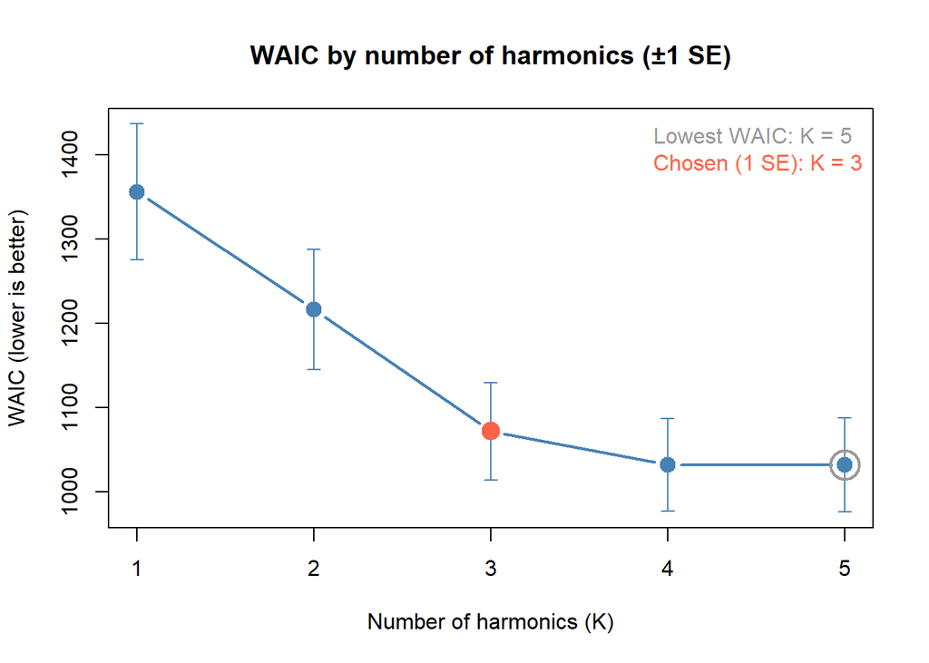

```r
ylim_k <- range(c(waic_logit - waic_logit_se, waic_logit + waic_logit_se))
plot(K_grid, waic_logit, type = "b", pch = 19, cex = 1.4,
     col = "steelblue", lwd = 2, ylim = ylim_k,
     xlab = "Number of harmonics (K)", ylab = "WAIC (lower is better)",
     main = "WAIC by number of harmonics (±1 SE)",
     xaxt = "n")
axis(1, at = K_grid)
arrows(K_grid, waic_logit - waic_logit_se, K_grid, waic_logit + waic_logit_se,
       angle = 90, code = 3, length = 0.05, col = "steelblue")
points(lowest_K, waic_logit[which.min(waic_logit)],
       col = "gray60", pch = 1, cex = 3, lwd = 2)
points(best_K, waic_logit[which(K_grid == best_K)],
       col = "tomato", pch = 19, cex = 1.8)
legend("topright",
       legend = c(paste("Lowest WAIC: K =", lowest_K),
                  paste("Chosen (1 SE): K =", best_K)),
       text.col = c("gray60", "tomato"), bty = "n")
```

## Predicted probability curves

To construct the predictive curves, we evaluate the posterior mean of $P(z = h)$ across a continuous grid of hour values spanning from 0 to 23. For each posterior draw, we reconstruct the Fourier components, form the linear predictors from the sampled coefficients, apply the softmax transformation, and then average the resulting probabilities.

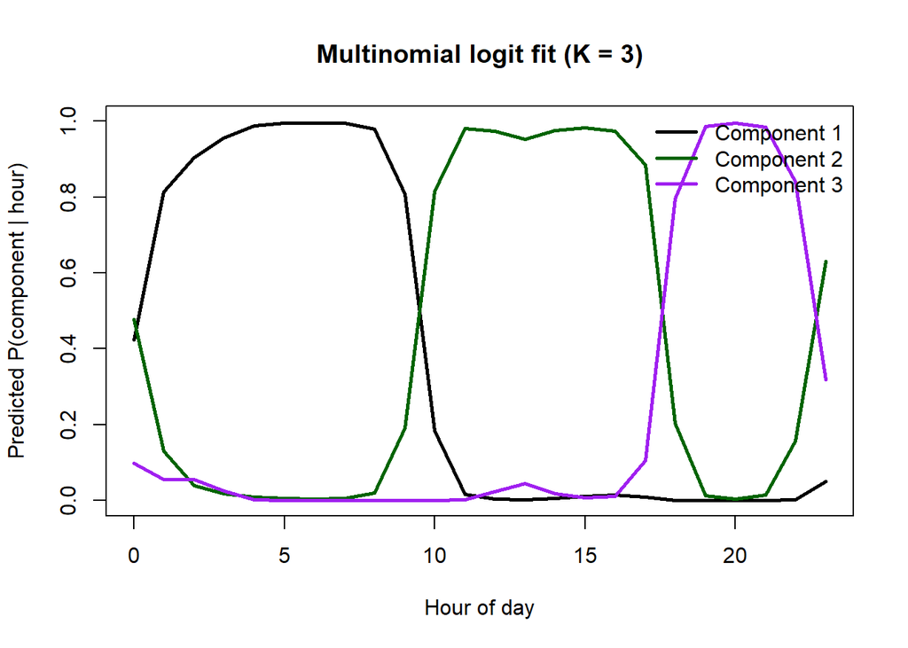

```r
best_fit  <- logit_fits[[which(K_grid == best_K)]]
best_coef <- reshape_logit_coefs(best_fit, best_H, best_K)

# Posterior-mean predicted probabilities P(z = h | hour) on the hour grid
hour_grid <- 0:23
P_pred    <- predict_logit_probs(best_coef, fourier_design(hour_grid, best_K), best_H)

matplot(hour_grid, P_pred, type = "l", lty = 1, lwd = 2.5,
        col = COMPONENT_COLS[1:best_H], ylim = c(0, 1),
        xlab = "Hour of day", ylab = "Predicted P(component | hour)",
        main = paste0("Multinomial logit fit (K = ", best_K, ")"))
legend("topright", legend = paste("Component", 1:best_H),
       col = COMPONENT_COLS[1:best_H], lwd = 2.5, lty = 1, bty = "n")
```

## Comparison with the empirical fractions of Task 3

Finally, we overlay the smooth logit-predicted curves (solid lines) onto the raw empirical fractions derived from Task 3 (points).

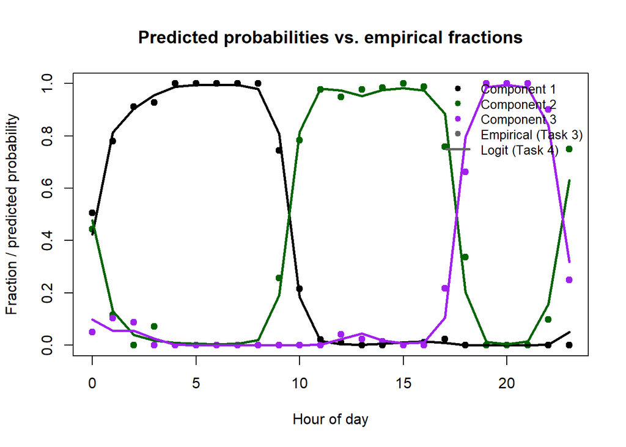

```r
matplot(0:23, as.matrix(frac_mat), type = "p", pch = 19,
        col = COMPONENT_COLS[1:best_H], ylim = c(0, 1),
        xlab = "Hour of day", ylab = "Fraction / predicted probability",
        main = "Predicted probabilities vs. empirical fractions")
matlines(hour_grid, P_pred, lty = 1, lwd = 2.5, col = COMPONENT_COLS[1:best_H])
legend("topright",
       legend = c(paste("Component", 1:best_H), "Empirical (Task 3)", "Logit (Task 4)"),
       col = c(COMPONENT_COLS[1:best_H], "gray40", "gray40"),
       pch = c(rep(19, best_H), 19, NA),
       lty = c(rep(NA, best_H), NA, 1),
       lwd = c(rep(NA, best_H), NA, 2.5),
       bty = "n", cex = 0.85)
```

# Prediction Exercise

To evaluate model generalization beyond the in-sample WAIC metric, we perform a held-out prediction exercise using an 80/20 randomized train/test split of the $N$ observations.

The multinomial logistic model with $K = K_{\text{best}}$ harmonics is refitted on the training subset. The resulting posterior distribution is used to predict the component labels of the test set based solely on the `hour` covariate.

**Evaluation Metrics:** We report the **log-loss** on the test set,
$$\text{log-loss} = -\frac{1}{N_\text{test}}\sum_{i
\in \text{test}}
\log \hat{P}(z_i = \hat z_{\text{map},i} \mid
\text{hour}_i),$$

and the **accuracy** (fraction of correctly predicted MAP labels). Both are compared against a **null baseline** that ignores `hour` entirely and predicts the empirical training class proportions.

```r
set.seed(42)
n_train_pred <- floor(0.8 * N)
train_pred   <- sample(seq_len(N), n_train_pred)
test_pred    <- setdiff(seq_len(N), train_pred)
n_test_pred  <- length(test_pred)

# Fourier designs for the training and test subsets
fb_tr <- fourier_design(hours[train_pred], best_K)
fb_te <- fourier_design(hours[test_pred],  best_K)

# Refit the logit on the training subset only
dat_tr <- list(z = z_map[train_pred], n = n_train_pred,
               H = best_H, K = best_K, S = fb_tr$S, C = fb_tr$C)
m_tr   <- jags.model(textConnection(jags_model_logit), data = dat_tr,
                     inits = make_inits(N_CHAINS), n.chains = N_CHAINS, quiet = TRUE)
update(m_tr, n.iter = N_BURNIN)
samp_tr <- jags.samples(m_tr,
                        variable.names = c("beta0", "alpha", "gamma"),
                        n.iter = N_SAMPLES)
```

```r
# Reshape the training-fit coefficients and predict on the test set [n_test x H]
coef_tr <- reshape_logit_coefs(samp_tr, best_H, best_K)
P_te    <- predict_logit_probs(coef_tr, fb_te, best_H)

# Log-loss and accuracy
z_te        <- z_map[test_pred]
pred_probs  <- sapply(seq_len(n_test_pred), function(i) P_te[i, z_te[i]])
log_loss_te <- -mean(log(pmax(pred_probs, 1e-10)))

z_pred_te   <- apply(P_te, 1, which.max)
acc_te      <- mean(z_pred_te == z_te)

# Null baseline: empirical class proportions from training set
train_props  <- tabulate(z_map[train_pred], nbins = best_H) / n_train_pred
baseline_ll  <- -mean(log(pmax(train_props[z_te], 1e-10)))
baseline_acc <- max(tabulate(z_map[train_pred])) / n_train_pred

pred_table <- data.frame(
  Metric   = c("Log-loss (lower is better)", "Accuracy (higher is better)"),
  Model    = round(c(log_loss_te, acc_te),       3),
  Baseline = round(c(baseline_ll, baseline_acc), 3)
)
cat("Prediction exercise (test set, n =", n_test_pred, ")\n")
```

```
## Prediction exercise (test set, n = 400 )
```

```r
print(pred_table, row.names = FALSE)
```

```
##                       Metric Model Baseline
##   Log-loss (lower is better) 0.276    1.114
##  Accuracy (higher is better) 0.900    0.395
```

The metrics indicate that `hour` is a genuinely informative covariate.  
This final plot compares the probability curves estimated exclusively from the 80% training subset against the empirical fractions derived from the full dataset (Task 3).

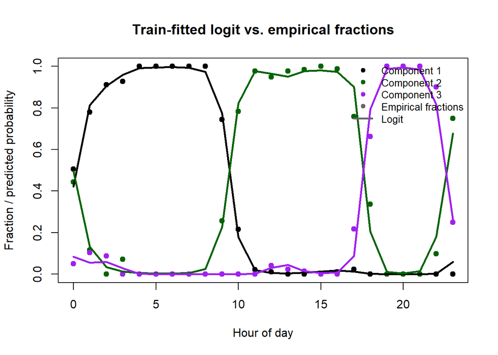

```r
# Compare probability curves from the train-only fit against the
# empirical fractions derived from the full data in Task 3.
# Close agreement means the model generalises: the periodic pattern
# learned on 80% of the data reproduces the full-data proportions.
hour_grid_p <- 0:23
P_grid <- predict_logit_probs(coef_tr, fourier_design(hour_grid_p, best_K), best_H)

matplot(0:23, as.matrix(frac_mat), type = "p", pch = 19,
        col = COMPONENT_COLS[1:best_H], ylim = c(0, 1),
        xlab = "Hour of day",
        ylab = "Fraction / predicted probability",
        main = "Train-fitted logit vs. empirical fractions")
matlines(hour_grid_p, P_grid, lty = 1, lwd = 2.5, col = COMPONENT_COLS[1:best_H])
legend("topright",
       legend = c(paste("Component", 1:best_H),
                  "Empirical fractions", "Logit"),
       col = c(COMPONENT_COLS[1:best_H], "gray40", "gray40"),
       pch = c(rep(19, best_H), 19, NA),
       lty = c(rep(NA,  best_H), NA,  1),
       lwd = c(rep(NA,  best_H), NA,  2.5),
       bty = "n", cex = 0.85)
```